# Regresja i analiza wariancji - Laboratorium 8

Regresja logistyczna - podstawy

Adrian Kowalski

Politechnika Krakowska

# zadanie klasyfikacji

Do tej pory zajmowaliśmy się zadaniem regresji, czyli chcieliśmy dopasować model do zmiennej ilościowej, zakładając, że przyjmuje ona wartości rzeczywiste. Zadanie klasyfikacyjne polega na dopasowaniu danej obserwajcji do jednej z kilku klas, czyli zmienna objaśniana jest jakościowa. W bardziej zaawansowanych algorytmach klasyfikacyjnych nie tylko dopasowywujemy do klas, ale zwracamy prawdopodobieństwo przynależności do danej klasy.

Do zadania klasyfikacji, gdy ilość klas jest większa niż 2 nie możemy użyć modelu regresji liniowej. Zilustrujemy to poniższym przykładem. Wczytamy słynny zbiór danych iris.

```r
library(tidyverse)
iris <- as.tibble(iris)
head(iris)
```

| Sepal.Length | Sepal.Width | Petal.Length | Petal.Width | Species |
| --- | --- | --- | --- | --- |
| 5.1 | 3.5 | 1.4 | 0.2 | setosa |
| 4.9 | 3.0 | 1.4 | 0.2 | setosa |
| 4.7 | 3.2 | 1.3 | 0.2 | setosa |
| 4.6 | 3.1 | 1.5 | 0.2 | setosa |
| 5.0 | 3.6 | 1.4 | 0.2 | setosa |
| 5.4 | 3.9 | 1.7 | 0.4 | setosa |

```r
unique(iris$Species)
```

```
[1] setosa     versicolor virginica
Levels: setosa versicolor virginica
```

Jak widać, w zbiorze mamy 3 różne klasy, do których należą nasze dane. Zakodujmy je za pomocą liczb $1,2,3$ na dwa różne sposoby.

```r
iris1 <- iris %>% dplyr::mutate(Species = ifelse(Species == 'setosa', 1, ifelse(Species == 'versicolor', 2, 3)))
head(iris1)
```

| Sepal.Length | Sepal.Width | Petal.Length | Petal.Width | Species |
| --- | --- | --- | --- | --- |
| 5.1 | 3.5 | 1.4 | 0.2 | 1 |
| 4.9 | 3.0 | 1.4 | 0.2 | 1 |
| 4.7 | 3.2 | 1.3 | 0.2 | 1 |
| 4.6 | 3.1 | 1.5 | 0.2 | 1 |
| 5.0 | 3.6 | 1.4 | 0.2 | 1 |
| 5.4 | 3.9 | 1.7 | 0.4 | 1 |

```r
iris2 <- iris %>% dplyr::mutate(Species = ifelse(Species == 'setosa', 2, ifelse(Species == 'versicolor', 3, 1)))
head(iris2)
```

| Sepal.Length | Sepal.Width | Petal.Length | Petal.Width | Species |
| --- | --- | --- | --- | --- |
| 5.1 | 3.5 | 1.4 | 0.2 | 2 |
| 4.9 | 3.0 | 1.4 | 0.2 | 2 |
| 4.7 | 3.2 | 1.3 | 0.2 | 2 |
| 4.6 | 3.1 | 1.5 | 0.2 | 2 |
| 5.0 | 3.6 | 1.4 | 0.2 | 2 |
| 5.4 | 3.9 | 1.7 | 0.4 | 2 |

Dopasujemy teraz model regresji liniowej, objaśniający tak zakodowaną zmienną.

```r
summary(lm(Species ~. , data = iris1))
```

```
Call:
lm(formula = Species ~ ., data = iris1)

Residuals:
     Min       1Q   Median       3Q      Max
-0.59215 -0.15368  0.01268  0.11089  0.55077

Coefficients:
             Estimate Std. Error t value Pr(>|t|)
(Intercept)   1.18650    0.20484   5.792 4.15e-08 ***
Sepal.Length -0.11191    0.05765  -1.941   0.0542 .
Sepal.Width  -0.04008    0.05969  -0.671   0.5030
Petal.Length  0.22865    0.05685   4.022 9.26e-05 ***
Petal.Width   0.60925    0.09446   6.450 1.56e-09 ***
---
Signif. codes:  0 ‘***’ 0.001 ‘**’ 0.01 ‘*’ 0.05 ‘.’ 0.1 ‘ ’ 1

Residual standard error: 0.2191 on 145 degrees of freedom
Multiple R-squared:  0.9304,    Adjusted R-squared:  0.9285
F-statistic: 484.5 on 4 and 145 DF,  p-value: < 2.2e-16
```

```r
summary(lm(Species ~., data=iris2))
```

```
Call:
lm(formula = Species ~ ., data = iris2)

Residuals:
    Min      1Q  Median      3Q     Max
-1.5145 -0.5207 -0.1267  0.5850  1.4936

Coefficients:
             Estimate Std. Error t value Pr(>|t|)
(Intercept)   4.27234    0.65702   6.503 1.19e-09 ***
Sepal.Length  0.02572    0.18490   0.139 0.889552
Sepal.Width  -0.64838    0.19145  -3.387 0.000911 ***
Petal.Length  0.21668    0.18235   1.188 0.236658
Petal.Width  -1.04609    0.30297  -3.453 0.000727 ***
---
Signif. codes:  0 ‘***’ 0.001 ‘**’ 0.01 ‘*’ 0.05 ‘.’ 0.1 ‘ ’ 1

Residual standard error: 0.7028 on 145 degrees of freedom
Multiple R-squared:  0.2839,    Adjusted R-squared:  0.2641
F-statistic: 14.37 on 4 and 145 DF,  p-value: 6.6e-10
```

To co można zauważyć, to wpływ tego jak zakodowaliśmy zmienne na wynik modelu. Taki efekt jest niedopuszczalny przy klasyfikacji, zatem regresja liniowa nie nadaje się do zadania klasyfikacji w wypadku, gdy mamy więcej niż 2 klasy. Co, gdy mamy dokładnie 2 klasy, czyli zadanie klasyfikacji jest tzw. zagadnieniem klasyfikacji binarnej. Wytnijmy ze zbioru Iris jedną ze zmiennych i dopasujmy model liniowy objaśniający Species.

```r
iris3 <- iris %>% dplyr::filter(Species != 'versicolor') %>%
          dplyr::mutate(Species = ifelse(Species == 'setosa', 0, 1))
head(iris3)
```

| Sepal.Length | Sepal.Width | Petal.Length | Petal.Width | Species |
| --- | --- | --- | --- | --- |
| 5.1 | 3.5 | 1.4 | 0.2 | 0 |
| 4.9 | 3.0 | 1.4 | 0.2 | 0 |
| 4.7 | 3.2 | 1.3 | 0.2 | 0 |
| 4.6 | 3.1 | 1.5 | 0.2 | 0 |
| 5.0 | 3.6 | 1.4 | 0.2 | 0 |
| 5.4 | 3.9 | 1.7 | 0.4 | 0 |

```r
class_linreg <- lm(Species ~., data=iris3)
summary(class_linreg)
```

```
Call:
lm(formula = Species ~ ., data = iris3)

Residuals:
      Min        1Q    Median        3Q       Max
-0.222085 -0.049792 -0.000438  0.045794  0.156436

Coefficients:
             Estimate Std. Error t value Pr(>|t|)
(Intercept)   0.30152    0.08471   3.559 0.000583 ***
Sepal.Length -0.07956    0.02409  -3.302 0.001353 **
Sepal.Width  -0.06037    0.02592  -2.329 0.021997 *
Petal.Length  0.18341    0.02202   8.331 6.02e-13 ***
Petal.Width   0.18462    0.03459   5.337 6.41e-07 ***
---
Signif. codes:  0 ‘***’ 0.001 ‘**’ 0.01 ‘*’ 0.05 ‘.’ 0.1 ‘ ’ 1

Residual standard error: 0.07198 on 95 degrees of freedom
Multiple R-squared:  0.9803,    Adjusted R-squared:  0.9795
F-statistic:  1183 on 4 and 95 DF,  p-value: < 2.2e-16
```

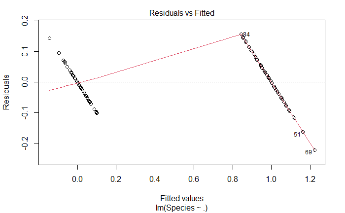

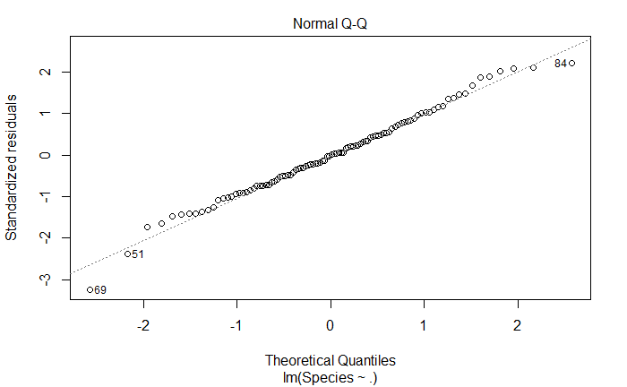

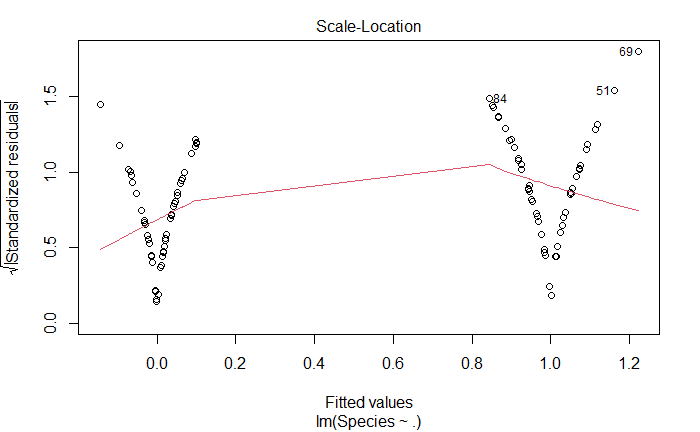

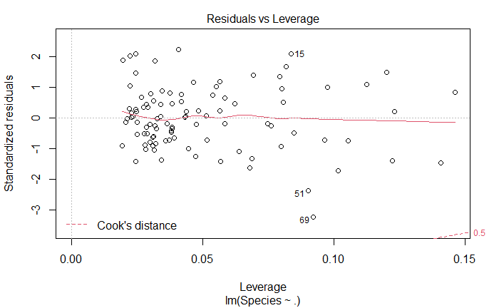

```r
plot(class_linreg, which=c(1:3,5))
```

W celach wizualizacji stwóżmy jeszcze model klasyfikacji oparty na regresji liniowej o dwóch zmiennych objaśniających. Wtedy możemy narzysować hiperpłaszczyzne decyzyjną, ponieważ jest ona prostą.

```r
db_linmodel <- lm(Species ~ Sepal.Length + Sepal.Width, data = iris3)
summary(db_linmodel)
```

```
Call:
lm(formula = Species ~ Sepal.Length + Sepal.Width, data = iris3)

Residuals:
     Min       1Q   Median       3Q      Max
-0.54239 -0.12927 -0.00167  0.11448  0.54021

Coefficients:
             Estimate Std. Error t value Pr(>|t|)
(Intercept)  -0.36916    0.22274  -1.657    0.101
Sepal.Length  0.40301    0.02172  18.551  < 2e-16 ***
Sepal.Width  -0.45833    0.04914  -9.327 3.81e-15 ***
---
Signif. codes:  0 ‘***’ 0.001 ‘**’ 0.01 ‘*’ 0.05 ‘.’ 0.1 ‘ ’ 1

Residual standard error: 0.1995 on 97 degrees of freedom
Multiple R-squared:  0.8457,    Adjusted R-squared:  0.8425
F-statistic: 265.7 on 2 and 97 DF,  p-value: < 2.2e-16
```

W celu wyznaczenia hiperpłaszczyzny decyzyjnej musimy wyznaczyć jej współczynniki. Robimy to rozwiązując równianie
$$\frac{1}{2} = \beta_0 + \beta_1x_1 + \beta_2x_2.$$

```r
bound_coeffs <- db_linmodel$coefficients
bc_bias <- -(bound_coeffs[1] - 1/2)/bound_coeffs[3]
bc_slope <- -bound_coeffs[2]/bound_coeffs[3]
c(bc_bias, bc_slope)
```

```
 (Intercept) Sepal.Length
  -1.8963517    0.8793085
```

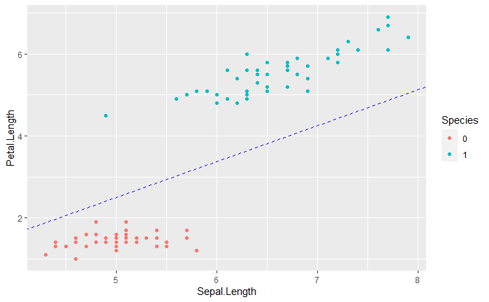

```r
ggplot(iris3, aes(x = Sepal.Length, y = Petal.Length, color = as.factor(Species))) + geom_point() + geom_abline(slope = bc_slope, intercept = bc_bias, color = 'blue', linetype = 'dashed') + labs(color = 'Species')
```

# Regresja logistyczna

Jednym z remediów na problemy regresji liniowej opisane powyżej (i pewne nieopisane powyżej - chociażby tzw. maskowanie klas) jest regresja logistyczna. Regresja logistyczna jest przykładem Uogólnionego Modelu Liniowego (GLM). Sformułujemy teraz model regresji logistycznej dla zadania klasyfikacji binarnej. Oznaczmy nasze klasy przez liczby $0,1$. Naszym punktem wyjścia jest założenie, że prawdopodobieństwo przynależności do klas można opisać wzorami
$$\mathbb{P}(Y = 0 | \mathbf{X}) = \frac{1}{1 + \mbox{exp}(\beta_0 + \beta^T\mathbf{x})},$$
gdzie $\beta = \left[\begin{array}{l} \beta_1 \\ \beta_2 \\ \dots \\ \beta_k \end{array} \right]$, natomiast
$$\mathbb{P}(Y = 1| \mathbf{x}) = \frac{\mbox{exp}(\beta_0 + \beta^T \mathbf{x})}{1 + \mbox{exp}(\beta_0 + \beta^T \mathbf{x})} = \left( \frac{1}{1 + e^{-(\beta_0 + \beta^T\mathbf{x})}} \right).$$
Oznaczmy $\mathbb{P}(Y = 1 | \mathbf{X}) =: \hat{p}$. Zauważmy, że $\mathbb{P}(Y = 0 | \mathbf{X}) = 1 - \hat{p}$. Ponadto, zauważmy że $p \in [0,1]$. Zastosujmy teraz szereg przekształceń. Po pierwsze
$$\frac{p}{1-p} = e^{\beta_0 + \beta^T \mathbf{x}}.$$
Zauważmy, że $\frac{p}{1-p} > 0$, zatem możemy zlogarytmować powyższe wyrażenie i otrzymać tzw. funkcję logitową (log-odds)
$$\mbox{ln}\frac{p}{1-p} = \beta_0 + \beta^T \mathbf{x}.$$

Estymację współczynników modelu dokonujemy za pomocą metody największej wiarygodności, dla naszej postaci modelu przyjmuje ona postać
$$L(Y | \beta_0, \beta, \mathbf{X}) = \prod_{i=1}^n \hat{p}^{y_i}(1-\hat{p})^{1-y_i}.$$
Logwiarygodność zatem ma postać
$$\ell(Y | \beta_0, \beta, \mathbf{X}) = \sum_{i=1}^n y_iln\hat{p} + (1-y_i)ln(1- \hat{p}).$$
Często w literaturze można się spotkać z funkcją postaci $-\ell = -\sum_{i=1}^n y_iln\hat{p} + (1-y_i)ln(1- \hat{p})$, którą wtedy minimalizujemy i nazywamy entropią krzyżową lub stratą logarytmiczną (cross-entropy, log-loss). Niestety, optymalizacja tej funkcji nie jest możliwa w sposób analityczny, musismy kożystać z metod numerycznych takich jak chociażby gradient descent, czy metody quasi-Newtonowskie jak L-BFGS. W R regresję logistyczną wywołujemy poleceniem *glm* z parametrem *family*=‘binomial’.

```r
logistic1 <- glm(Species ~ Sepal.Length + Sepal.Width, data = iris3, family = 'binomial')
```

```
Warning: glm.fit: algorithm did not converge
Warning: glm.fit: fitted probabilities numerically 0 or 1 occurred
```

```r
summary(logistic1)
```

```
Call:
glm(formula = Species ~ Sepal.Length + Sepal.Width, family = "binomial",
    data = iris3)

Deviance Residuals:
       Min          1Q      Median          3Q         Max
-8.826e-05  -2.100e-08   0.000e+00   2.100e-08   9.689e-05

Coefficients:
             Estimate Std. Error z value Pr(>|z|)
(Intercept)    -445.9   153423.2  -0.003    0.998
Sepal.Length    166.6    54421.0   0.003    0.998
Sepal.Width    -140.6    52362.6  -0.003    0.998

(Dispersion parameter for binomial family taken to be 1)

    Null deviance: 1.3863e+02  on 99  degrees of freedom
Residual deviance: 1.8331e-08  on 97  degrees of freedom
AIC: 6

Number of Fisher Scoring iterations: 25
```

```r
heart <- readr::read_csv('heart.csv')
head(heart)
```

| Age | Sex | ChestPainType | RestingBP | Cholesterol | FastingBS | RestingECG | MaxHR | ExerciseAngina | Oldpeak | ST_Slope | HeartDisease |
| --- | --- | --- | --- | --- | --- | --- | --- | --- | --- | --- | --- |
| 40 | M | ATA | 140 | 289 | 0 | Normal | 172 | N | 0.0 | Up | 0 |
| 49 | F | NAP | 160 | 180 | 0 | Normal | 156 | N | 1.0 | Flat | 1 |
| 37 | M | ATA | 130 | 283 | 0 | ST | 98 | N | 0.0 | Up | 0 |
| 48 | F | ASY | 138 | 214 | 0 | Normal | 108 | Y | 1.5 | Flat | 1 |
| 54 | M | NAP | 150 | 195 | 0 | Normal | 122 | N | 0.0 | Up | 0 |
| 39 | M | NAP | 120 | 339 | 0 | Normal | 170 | N | 0.0 | Up | 0 |

```r
table(heart$HeartDisease)
```

```
  0   1
410 508
```

Zbudujmy prosty model regresji logistycznej z dwoma predyktorami.

```r
logistic2 <- glm(HeartDisease ~ Cholesterol + RestingBP, data = heart, family = 'binomial')
summary(logistic2)
```

```
Call:
glm(formula = HeartDisease ~ Cholesterol + RestingBP, family = "binomial",
    data = heart)

Deviance Residuals:
    Min       1Q   Median       3Q      Max
-2.0660  -1.1644   0.6868   1.0990   1.9921

Coefficients:
              Estimate Std. Error z value Pr(>|z|)
(Intercept) -0.8830052  0.5151740  -1.714   0.0865 .
Cholesterol -0.0050437  0.0006999  -7.206 5.74e-13 ***
RestingBP    0.0160623  0.0039091   4.109 3.97e-05 ***
---
Signif. codes:  0 ‘***’ 0.001 ‘**’ 0.01 ‘*’ 0.05 ‘.’ 0.1 ‘ ’ 1

(Dispersion parameter for binomial family taken to be 1)

    Null deviance: 1262.1  on 917  degrees of freedom
Residual deviance: 1192.7  on 915  degrees of freedom
AIC: 1198.7

Number of Fisher Scoring iterations: 4
```

Hiperpłaszczyzna decyzyjna w wypadku regresji logistycznej jest rozwiązaniem równania
$$\frac{1}{2} = \hat{p}.$$

```r
dec_bond <- logistic2$coefficients
logistic2_slope = -dec_bond[2]/dec_bond[3]
logistic2_intercept = -dec_bond[1]/dec_bond[3]
```

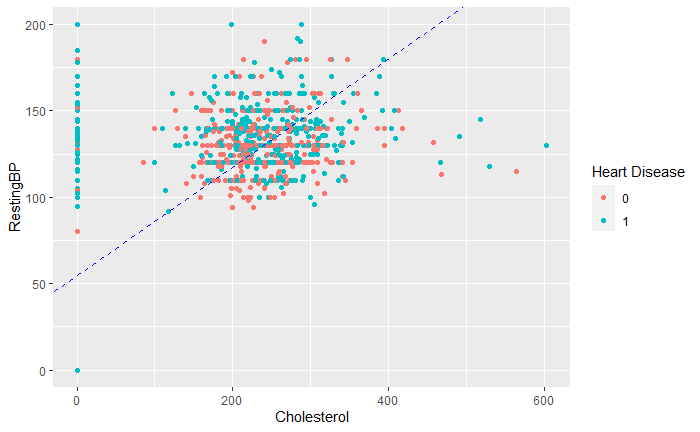

```r
ggplot(heart, aes(x = Cholesterol, y = RestingBP, color = as.factor(HeartDisease))) + geom_point() + geom_abline(slope = logistic2_slope, intercept = logistic2_intercept, color = 'blue', linetype = 'dashed') +
    labs(color = 'Heart Disease')
```

# Walidacja jakości modelu

Modele porównywać możemy między sobą na podstawie kryterium Akaikego (AIC), natomiast ocena konkretnego modelu przebiega za pomocą macierzy pomyłek. Stworzymy ją za pomocą biblioteki *caret*.

```r
logit_prediction <- predict(logistic2, heart[c(4,5)], type = 'response')
head(logit_prediction)
```

```
        1         2         3         4         5         6
0.4770383 0.6854860 0.4446596 0.5632204 0.6324683 0.3395403
```

```r
logistic2_predictions <- ifelse(logit_prediction > 0.5, 1, 0)
head(logistic2_predictions)
```

```
1 2 3 4 5 6
0 1 0 1 1 0
```

```r
library(caret)
caret::confusionMatrix(data = as.factor(logistic2_predictions), reference = as.factor(heart$HeartDisease))
```

```
Confusion Matrix and Statistics

          Reference
Prediction   0   1
         0 192 158
         1 218 350

               Accuracy : 0.5904
                 95% CI : (0.5578, 0.6224)
    No Information Rate : 0.5534
    P-Value [Acc > NIR] : 0.012889

                  Kappa : 0.1595

 Mcnemar's Test P-Value : 0.002345

            Sensitivity : 0.4683
            Specificity : 0.6890
         Pos Pred Value : 0.5486
         Neg Pred Value : 0.6162
             Prevalence : 0.4466
         Detection Rate : 0.2092
   Detection Prevalence : 0.3813
      Balanced Accuracy : 0.5786

       'Positive' Class : 0
```

# Ćwiczenie

Używając kryterium Akaikego i macierzy pomyłek dopasuj model regresji logistycznej do danych heart.